# Metagenomic assessment of the diversity and ubiquity of antimicrobial resistance genes in Bangladeshi aquaculture ponds

Ashley G. Bell<sup>a,b*</sup>, Kelly Thornber<sup>a,b</sup>, Dominique L. Chaput<sup>a,b</sup>, Neaz A. Hasan<sup>c</sup>, Md. Mehedi Alam<sup>c</sup>, Mohammad Mahfujul Haque<sup>c</sup>, Jo Cable<sup>d</sup>, Ben Temperton<sup>a</sup>, Charles R. Tyler<sup>a,b</sup>

<sup>a</sup> College of Life & Environmental Sciences, The University of Exeter, Exeter, Devon, EX4 4QD, United Kingdom

<sup>b</sup> Sustainable Aquaculture Futures, The University of Exeter, Exeter, Devon, EX4 4QD, United Kingdom

<sup>c</sup> Department of Aquaculture, Bangladesh Agricultural University, Mymensingh, Bangladesh

<sup>d</sup> School of Biosciences, Cardiff University, Cardiff, CF10 3AX, United Kingdom

* Corresponding author

## Article

https://doi.org/10.1016/j.aqrep.2023.101462

## Preprint

https://doi.org/10.1101/2022.09.14.507951

## Abstract

In Bangladesh, fish provide over 60% of animal-source food with 56.2% of this coming from aquaculture produced predominantly in rural freshwater ponds. Increasing demand for fish products is driving intensification and resulting in higher disease prevalence, posing a risk to food security. Biosecurity is often absent in rural aquaculture practices in Bangladesh and antibiotics are commonly used to treat and prevent disease outbreaks. Antibiotics are often administered incorrectly - a key factor associated with the development of antimicrobial resistance (AMR). AMR can be disseminated rapidly within microbial ecosystems via mobile genetic elements, posing a risk for humans and animals infected with AMR pathogens as treatments with antibiotics become ineffective. Early AMR detection and understanding of the spread of antimicrobial resistance genes (ARGs) in rural aquaculture practices is critical for both food security, human health protection and food safety. Here, we apply a metagenomic approach to assess the ARG composition in pond water from six finfish (tilapia and pangasius) farms in the Mymensingh division of North-central Bangladesh. We found microbial communities within the ponds had similar alpha and beta diversities, with multiple ARGs predicted to confer resistance to eighteen different classes of antimicrobials. The most common ARGs conferred resistance to aminoglycosides and sulphonamides and were present in taxa associated with both fish and human pathogens. This ARG diversity potentially confers resistance to a wide variety of antibiotic classes and questions the effectiveness of current and future treatment of diseases with antibiotics in earthen aquaculture ponds. The microbial and ARG compositions between fish ponds within each farm were similar, which may relate to parallels in farming practices creating similar microbial selection pressures and thus comparable microbial populations. Without a more controlled approach towards antibiotic usage, we will inevitably further exacerbate the challenges in treating and preventing disease outbreaks as aquaculture production intensifies in Bangladesh.

### Keywords:

Antimicrobial resistance, Bangladesh, Fish pond, Microbiome, Aquaculture, Plasmid

## Highlights

- ARGs in Bangladesh rural fishponds indicate resistance to 18 different antibiotics.
- The most common AMR were to aminoglycosides and sulphonamides.
- ARGs were present in plasmids and taxa-associated pathogens.
- Farming practices strongly influence microbial and ARG compositions.
- Identified ARGs question antibiotic treatment of disease in rural aquaculture.

**Figure 1. A)** Regional map of the Mymensingh division of North-central Bangladesh. Fish farm locations within villages are labelled F1, F2, F3, F4, F5, F6 and corresponding Upazilas are highlighted with an inset showing a map of Bangladesh with the Mymensingh division highlighted in light grey. Farm locations are jittered slightly to preserve farmer anonymity. **B)** Sampling regime schematic with pond water samples collected and pooled from six different Bangladesh finfish aquaculture farms (two or three ponds per farm) in three Upazilas and over four seasonal periods.

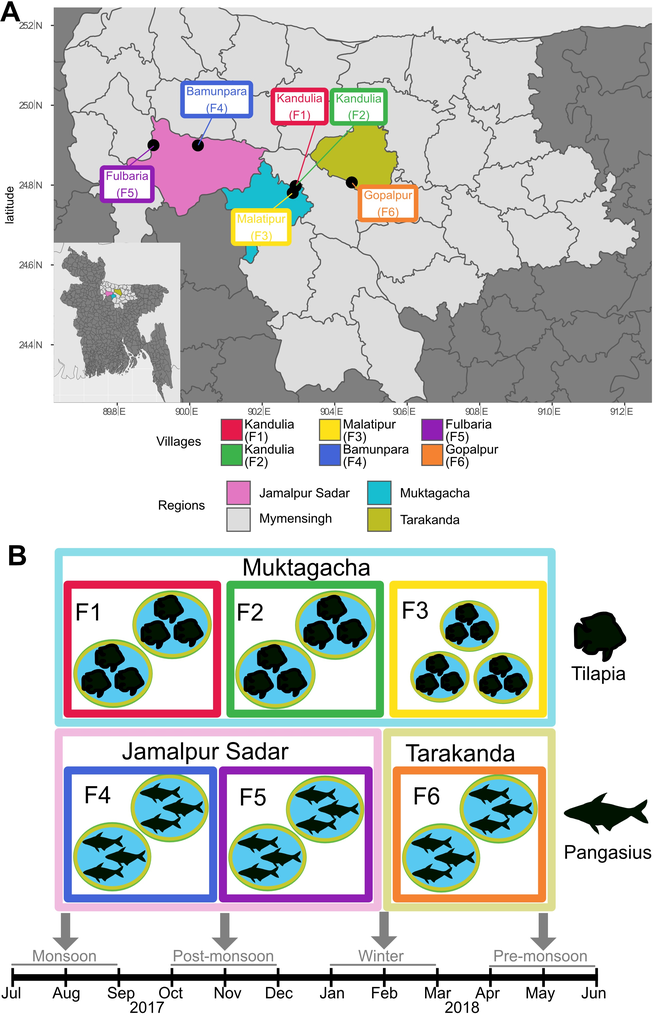

Regional map of the Mymensingh division of North-central Bangladesh